# Exploratory Data Analysis by Skandarajan Rajaratnam

## Introduction

Exploring the univariate, bivariate, & multivariate relationships between variables with data analysis techniques in R. This tidy data set contains 1,599 red wines with 11 variables on the chemical properties of the wine.

Number of Instances: Red wine - 1599

Number of Attributes: 11 + output attribute

Input variables (based on physicochemical tests):

1 - fixed acidity (tartaric acid - g / dm^3): Most acids involved with wine or fixed or nonvolatile.

2 - volatile acidity (acetic acid - g / dm^3): The amount of acetic acid in wine, which at too high of levels can lead to an unpleasant, vinegar taste

3 - citric acid (g / dm^3): Found in small quantities, citric acid can add ‘freshness’ and flavor to wine

4 - residual sugar (g / dm^3): The amount of sugar remaining after fermentation stops, it’s rare to find wines with less than 1 gram/liter and wines with greater than 45 grams/liter are considered sweet

5 - chlorides (sodium chloride - (g / dm^3): The amount of salt in the wine

6 - free sulfur dioxide (mg / dm^3): The free form of SO2 exists in equilibrium between molecular SO2 and bisulfite ion; it prevents microbial growth and the oxidation of wine

7 - total sulfur dioxide (mg / dm^3): Amount of free and bound forms of S02; in low concentrations, SO2 is mostly undetectable in wine, but at free SO2 concentrations over 50 ppm, SO2 becomes evident in the nose and taste of wine

8 - density (g / cm^3): The density of water is close to that of water depending on the percent alcohol and sugar content

9 - pH: Describes how acidic or basic a wine is on a scale from 0 (very acidic) to 14 (very basic); most wines are between 3-4 on the pH scale

10 - sulphates (potassium sulphate - g / dm3): A wine additive which can contribute to sulfur dioxide gas (S02) levels, wich acts as an antimicrobial and antioxidant

11 - alcohol (% by volume): The percent alcohol content of the wine.

Output variable (based on sensory data):

12 - quality (score between 0 and 10)

Required Packages ara loaded.

```
##   X fixed.acidity volatile.acidity citric.acid residual.sugar chlorides
## 1 1           7.4             0.70        0.00            1.9     0.076
## 2 2           7.8             0.88        0.00            2.6     0.098
## 3 3           7.8             0.76        0.04            2.3     0.092
## 4 4          11.2             0.28        0.56            1.9     0.075
## 5 5           7.4             0.70        0.00            1.9     0.076
## 6 6           7.4             0.66        0.00            1.8     0.075
##   free.sulfur.dioxide total.sulfur.dioxide density   pH sulphates alcohol
## 1                  11                   34  0.9978 3.51      0.56     9.4
## 2                  25                   67  0.9968 3.20      0.68     9.8
## 3                  15                   54  0.9970 3.26      0.65     9.8
## 4                  17                   60  0.9980 3.16      0.58     9.8
## 5                  11                   34  0.9978 3.51      0.56     9.4
## 6                  13                   40  0.9978 3.51      0.56     9.4
##   quality
## 1       5
## 2       5
## 3       5
## 4       6
## 5       5
## 6       5
```

```
##         X fixed.acidity volatile.acidity citric.acid residual.sugar
## 1590 1590           6.6            0.725        0.20            7.8
## 1591 1591           6.3            0.550        0.15            1.8
## 1592 1592           5.4            0.740        0.09            1.7
## 1593 1593           6.3            0.510        0.13            2.3
## 1594 1594           6.8            0.620        0.08            1.9
## 1595 1595           6.2            0.600        0.08            2.0
## 1596 1596           5.9            0.550        0.10            2.2
## 1597 1597           6.3            0.510        0.13            2.3
## 1598 1598           5.9            0.645        0.12            2.0
## 1599 1599           6.0            0.310        0.47            3.6
##      chlorides free.sulfur.dioxide total.sulfur.dioxide density   pH
## 1590     0.073                  29                   79 0.99770 3.29
## 1591     0.077                  26                   35 0.99314 3.32
## 1592     0.089                  16                   26 0.99402 3.67
```

[output cut: 18 more lines]

```
## 'data.frame':    1599 obs. of  13 variables:
##  $ X                   : int  1 2 3 4 5 6 7 8 9 10 ...
##  $ fixed.acidity       : num  7.4 7.8 7.8 11.2 7.4 7.4 7.9 7.3 7.8 7.5 ...
##  $ volatile.acidity    : num  0.7 0.88 0.76 0.28 0.7 0.66 0.6 0.65 0.58 0.5 ...
##  $ citric.acid         : num  0 0 0.04 0.56 0 0 0.06 0 0.02 0.36 ...
##  $ residual.sugar      : num  1.9 2.6 2.3 1.9 1.9 1.8 1.6 1.2 2 6.1 ...
##  $ chlorides           : num  0.076 0.098 0.092 0.075 0.076 0.075 0.069 0.065 0.073 0.071 ...
##  $ free.sulfur.dioxide : num  11 25 15 17 11 13 15 15 9 17 ...
##  $ total.sulfur.dioxide: num  34 67 54 60 34 40 59 21 18 102 ...
##  $ density             : num  0.998 0.997 0.997 0.998 0.998 ...
##  $ pH                  : num  3.51 3.2 3.26 3.16 3.51 3.51 3.3 3.39 3.36 3.35 ...
##  $ sulphates           : num  0.56 0.68 0.65 0.58 0.56 0.56 0.46 0.47 0.57 0.8 ...
##  $ alcohol             : num  9.4 9.8 9.8 9.8 9.4 9.4 9.4 10 9.5 10.5 ...
##  $ quality             : int  5 5 5 6 5 5 5 7 7 5 ...
```

Structure of the dataset?

The dataset is contains 1,599 observations with 11 variables.Variables are of classes integer and numeric. The quality is scored in numbers. I am creating a new variable called “total_acidity”. Also creating a “quality_bucket” categorical varible to analyse the quality of the wine as a grroup.

# Univariate Plots Section

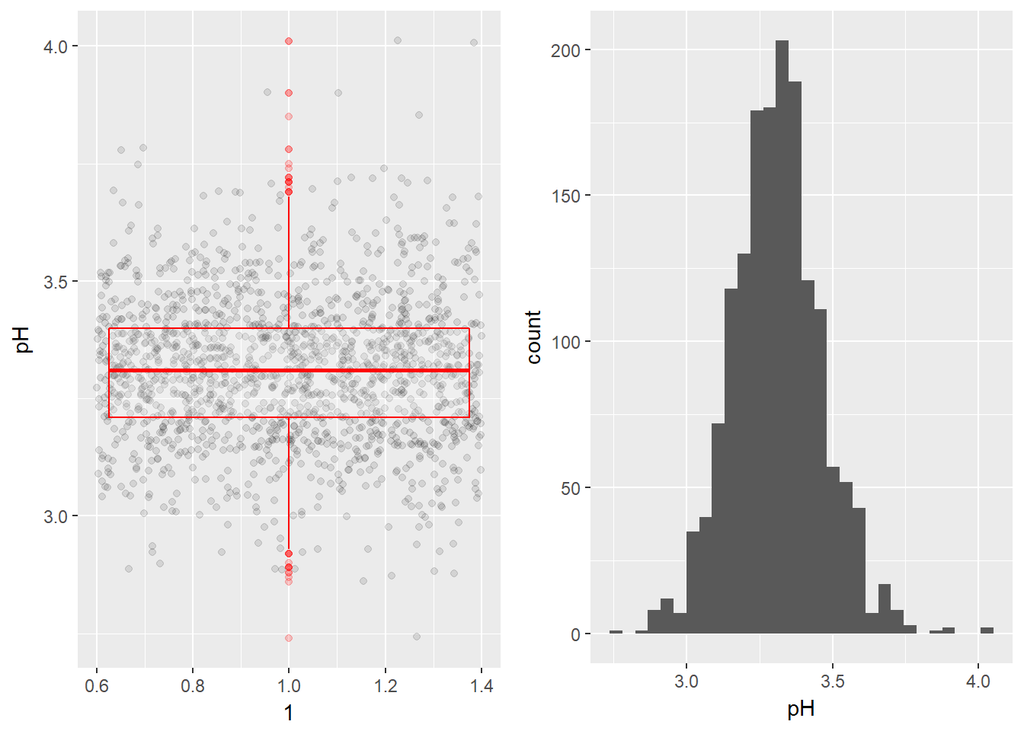

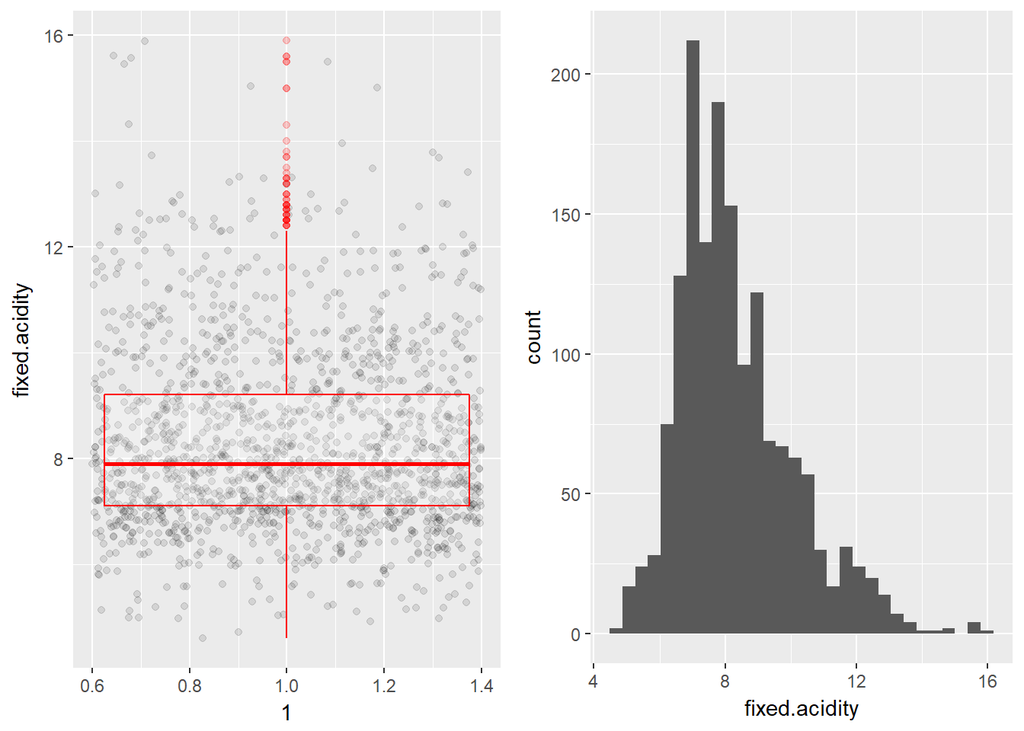

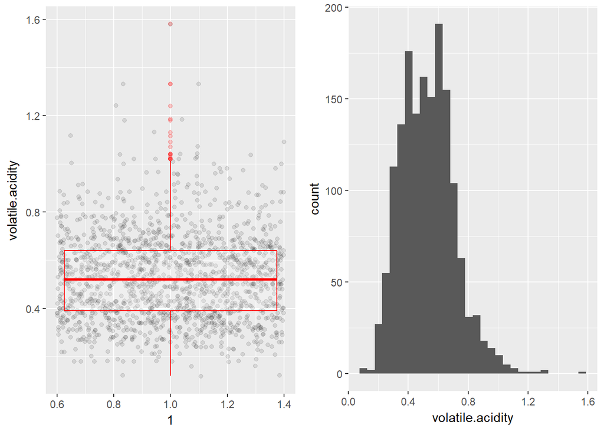

The distribution of Volatile acidity looks like Bimodal with two peaks around 0.4 and 0.6.

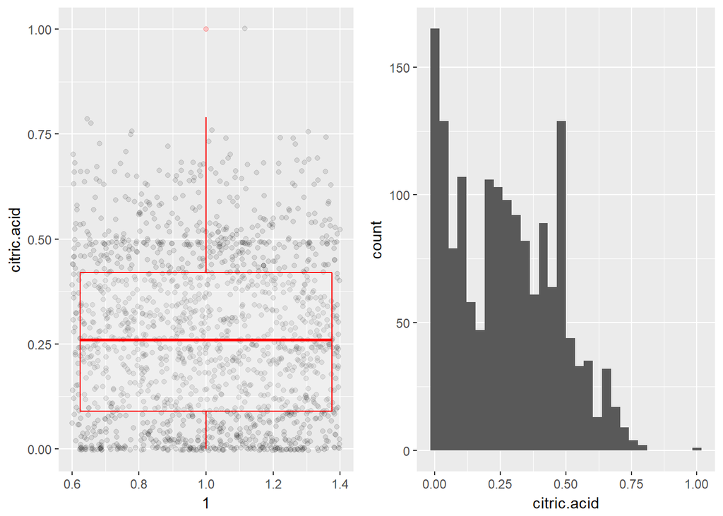

Apart from some outliers, the distribution of Citric acid looks strange. Some higher values have no data at all and apart from them, the distribution looks almost rectangular.

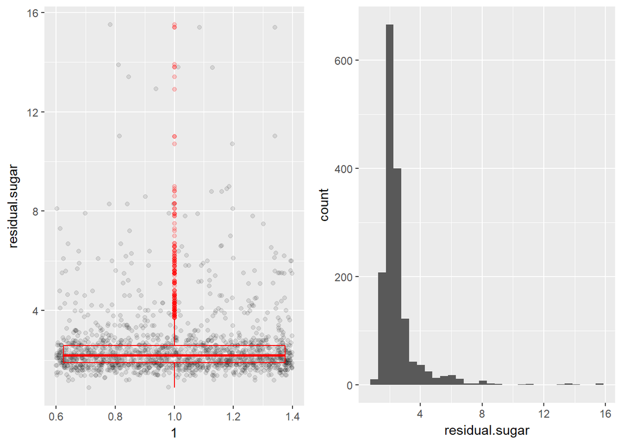

The distribution of Residual Sugar is again positively skewed with high peaks at around 2 with many outliers present at the higher ranges.

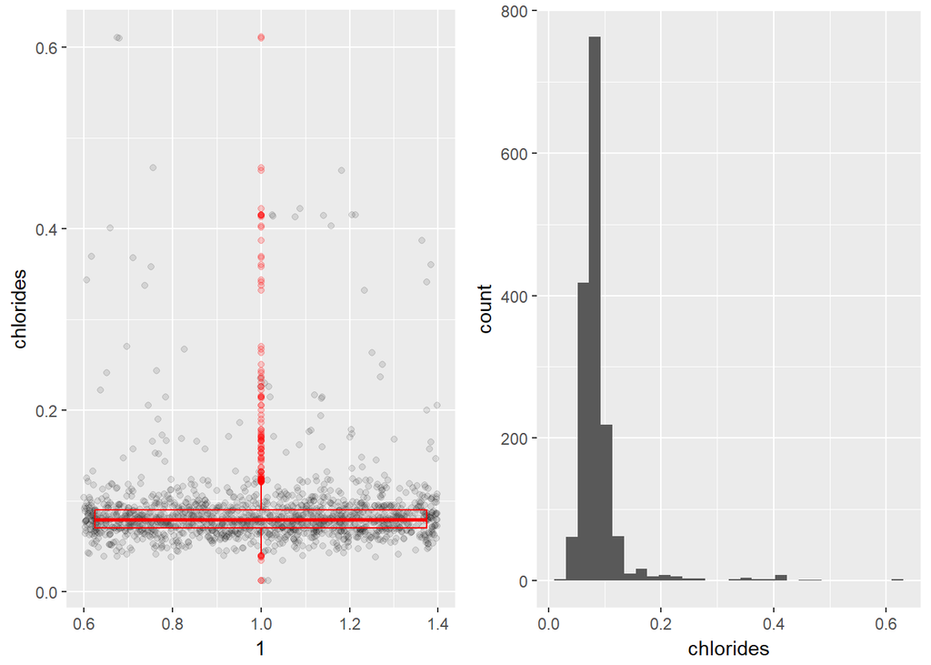

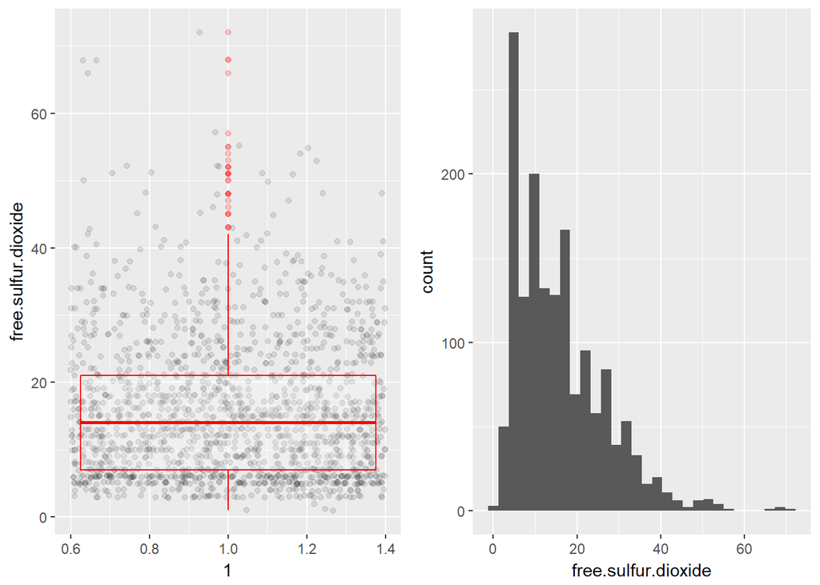

Free Sulphur Dioxide, there is a high peak at 4.5 but then it again follows the same positively skewed long tailed patterns with some outliers in the high range.

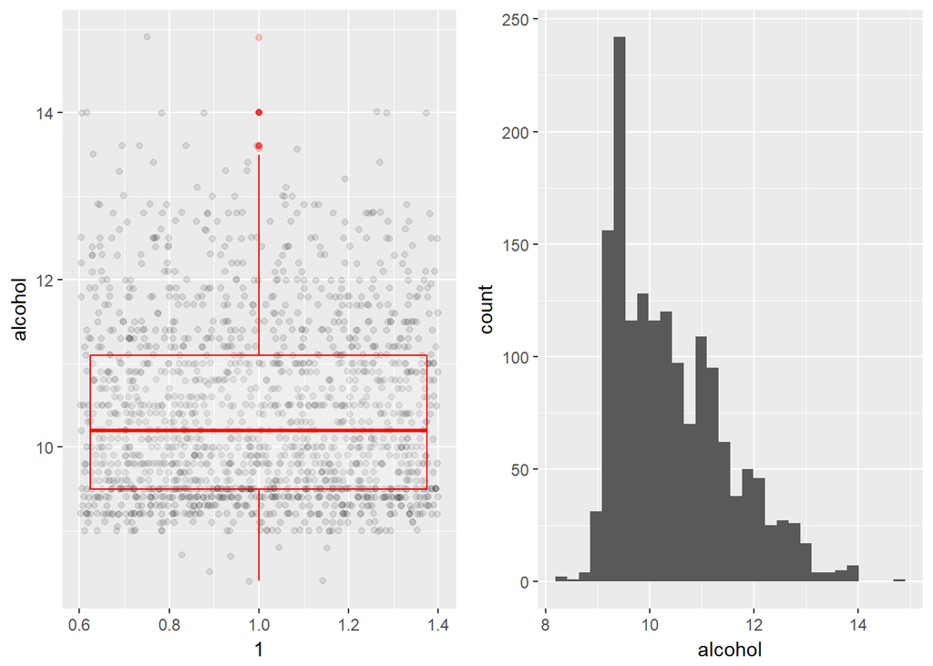

Alcohol also a skewed distribution. Here the skewness is less than that of Chlorides or Residual Sugars.

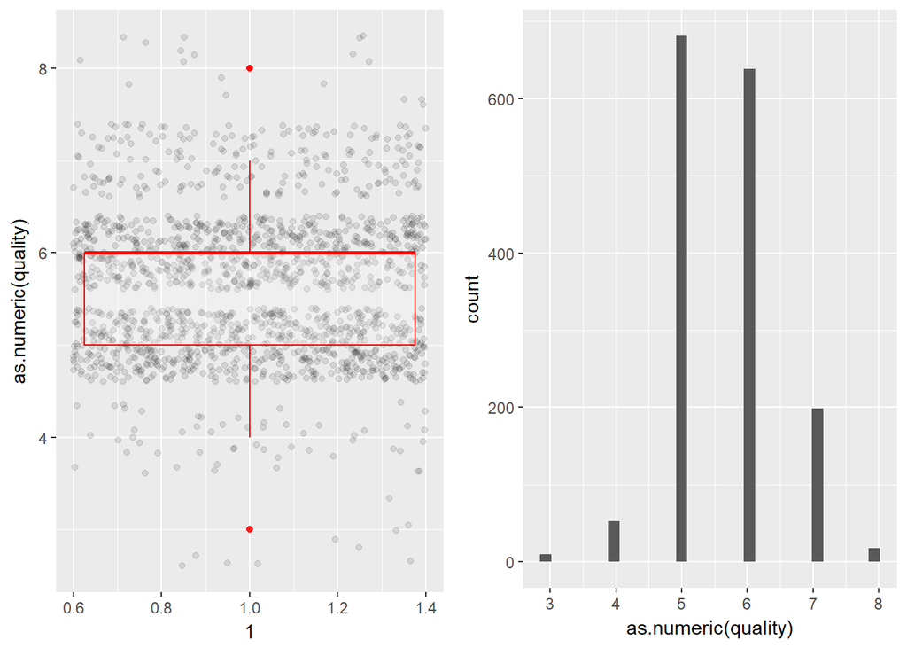

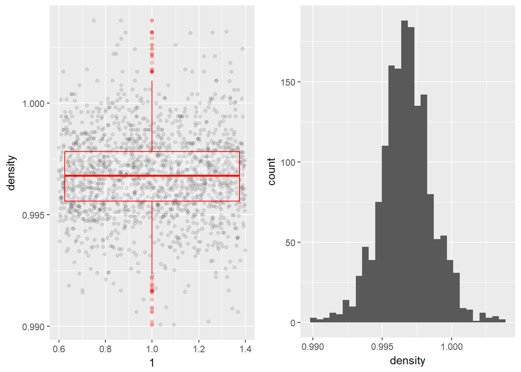

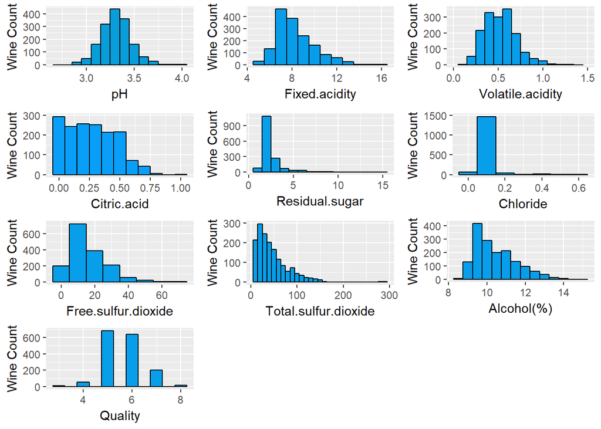

I try to get more about dataset, How are they related to each other. Also trying to get a pattern and the behaviour of each features. Noticed that the ph is a bell curve with the wine count. It is a Standard normal distribution. The Fixed acidity is roughty skewed with wine count, Volatility is also has a Standard normal distribution with the wine count. Citric acid does not seems to be vary with the wine count.

Residual.sugar, chlorides, free.sulfur.dioxide, total.sulfur.dioxide are right skewed distribution with the wine count. They are long tailed in the right side. Medium quality wine are double trible the count than low and high quality. Seems like normaly distributed.No variation in the density.

Calculate Total acids in the red wines, I create a new variable called total_acidity.

```
## [1]  8.10  8.68  8.60 12.04  8.10  8.06
```

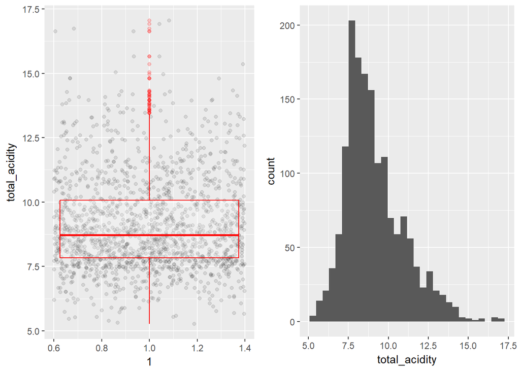

Quality of wine It is scored by numbers 0 - 10. I am going to make a bucket

0-3: Low Quality

4-6: Medium Quality

7-10: High Quality

Transform quality from an integer to a categorical parameter.

```
## [1] Medium Quality Medium Quality Medium Quality Medium Quality
## [5] Medium Quality Medium Quality
## Levels: Low Quality < Medium Quality < High Quality
```

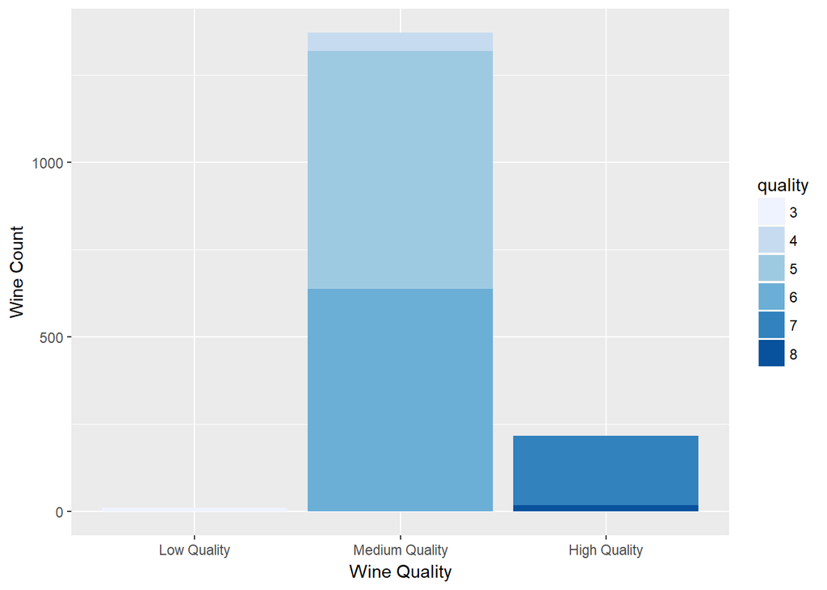

From the plot, we can see medium quality wine are produced more or more in demand in the market place.

# Univariate Analysis

#### 1. What is the structure of your dataset?

The dataset is contains 1,599 observations with 11 variables.Variables are of classes int and numeric. The quality is scored in numbers. I am creating a new variable called “total_acid”. Also creating a quality_bucket categorical varible. Total 1,599 observationa and 13 Variables.

#### 2. What is/are the main feature(s) of interest in your dataset?

Taste / Tactile - The tongue only can sense taste and feel texture. It senses sweetness (the presence of sugar), sourness (the presence of acidity), bitterness and saltiness. In addition, it can feel heat from alcohol. I am interested in how these 11 varibleas are influnceing the above senses . Mainly how the acidity and the percentage of alcohol influencing the tase and the quality of the red wine. How the risidual sugar has influence the sweet and quality of the wine. I’d like to determine which features are best for predicting the quality of the Red wine and also which factor bring more demand on red wines.

#### 3. What other features in the dataset do you think will help support your investigation into your feature(s) of interest?

I think acidity, sulfur, residual sugar, sulphates and alcohol are likely contribute to the quality of wine. I think acidity and sulfur probably contribute most to the quality of the wine.

#### 4. Did you create any new variables from existing variables in the dataset?

I created a variable for the total acidity of the red wine to analyze how the acidity influencing the wine quality. Also created categorical variable “quality _bucket" to have the quality to classify the wines into 3 categories Low, Midium and High Quality.

#### 5. The features you investigated, were there any unusual distributions? Did you perform any operations on the data to tidy, adjust, or change the form of the data? If so, why did you do this?

# Bivariate Plots Section

We can see strong relation ship betwwen fixed acidity Vs density (0.7) fixed acidity Vs citric acid (0.7) fixed acidity Vs pH (-0.7) Alcohol Vs density (-0.5)

```
##        X          fixed.acidity   volatile.acidity  citric.acid
##  Min.   :   1.0   Min.   : 4.60   Min.   :0.1200   Min.   :0.000
##  1st Qu.: 400.5   1st Qu.: 7.10   1st Qu.:0.3900   1st Qu.:0.090
##  Median : 800.0   Median : 7.90   Median :0.5200   Median :0.260
##  Mean   : 800.0   Mean   : 8.32   Mean   :0.5278   Mean   :0.271
##  3rd Qu.:1199.5   3rd Qu.: 9.20   3rd Qu.:0.6400   3rd Qu.:0.420
##  Max.   :1599.0   Max.   :15.90   Max.   :1.5800   Max.   :1.000
##  residual.sugar     chlorides       free.sulfur.dioxide
##  Min.   : 0.900   Min.   :0.01200   Min.   : 1.00
##  1st Qu.: 1.900   1st Qu.:0.07000   1st Qu.: 7.00
##  Median : 2.200   Median :0.07900   Median :14.00
##  Mean   : 2.539   Mean   :0.08747   Mean   :15.87
##  3rd Qu.: 2.600   3rd Qu.:0.09000   3rd Qu.:21.00
##  Max.   :15.500   Max.   :0.61100   Max.   :72.00
##  total.sulfur.dioxide    density             pH          sulphates
##  Min.   :  6.00       Min.   :0.9901   Min.   :2.740   Min.   :0.3300
##  1st Qu.: 22.00       1st Qu.:0.9956   1st Qu.:3.210   1st Qu.:0.5500
##  Median : 38.00       Median :0.9968   Median :3.310   Median :0.6200
##  Mean   : 46.47       Mean   :0.9967   Mean   :3.311   Mean   :0.6581
##  3rd Qu.: 62.00       3rd Qu.:0.9978   3rd Qu.:3.400   3rd Qu.:0.7300
##  Max.   :289.00       Max.   :1.0037   Max.   :4.010   Max.   :2.0000
##     alcohol      quality total_acidity           quality_bucket
##  Min.   : 8.40   3: 10   Min.   : 5.270   Low Quality   :  10
##  1st Qu.: 9.50   4: 53   1st Qu.: 7.827   Medium Quality:1372
##  Median :10.20   5:681   Median : 8.720   High Quality  : 217
##  Mean   :10.42   6:638   Mean   : 9.118
##  3rd Qu.:11.10   7:199   3rd Qu.:10.070
##  Max.   :14.90   8: 18   Max.   :17.045
```

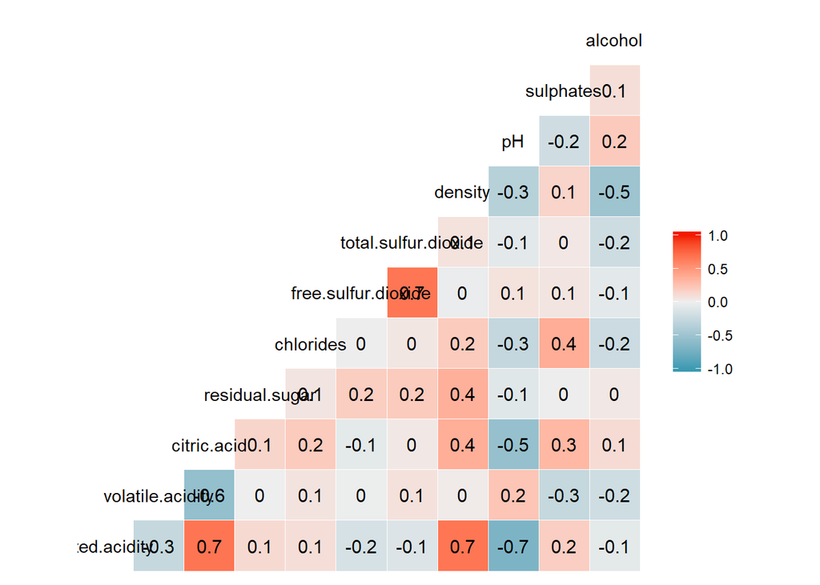

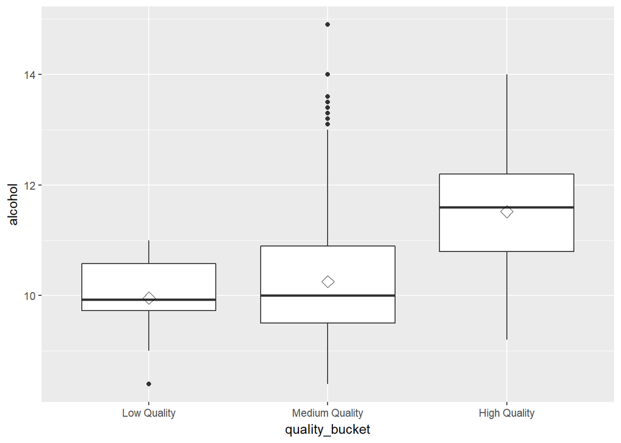

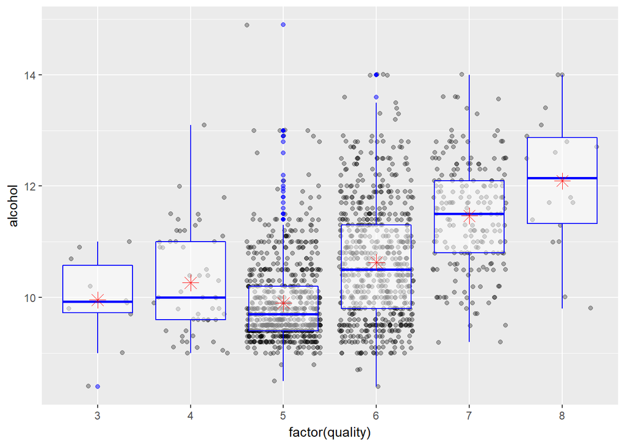

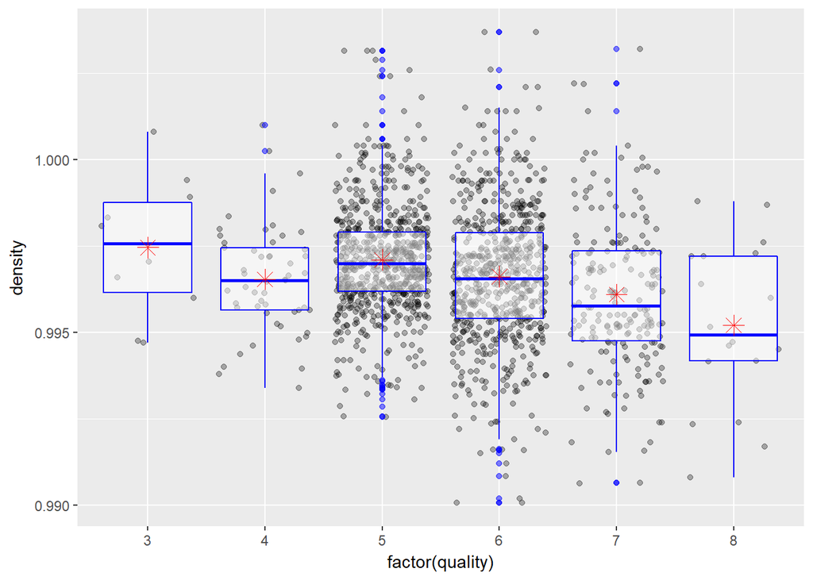

Better wines seems to have lower densities.Because there might be a possibility that the low density is due to higher alcohol content which actually is the driving factor for better wine.

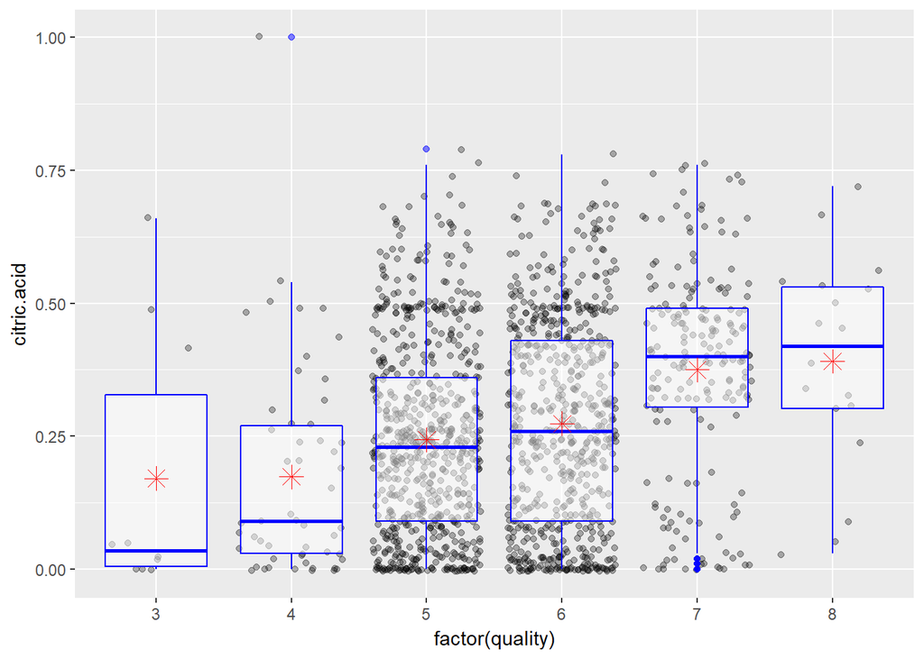

Citric acid seems to have a positive correlation with Wine Quality. Better wines have higher Citric Acid.

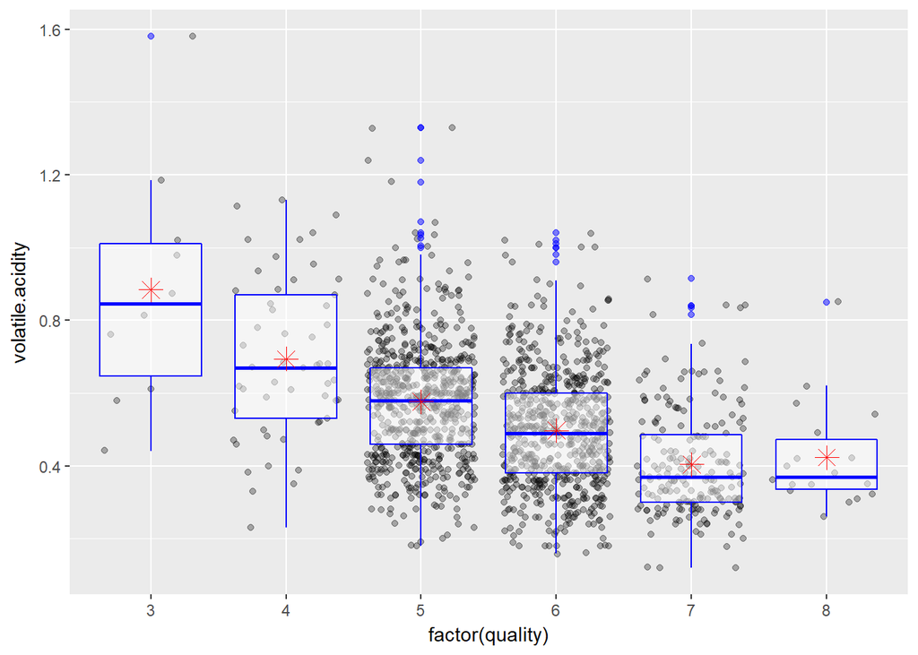

Volatile acid seems to have a negative impact on the quality of the wine. As volatile acid level goes up, the quality of the wine degrades.

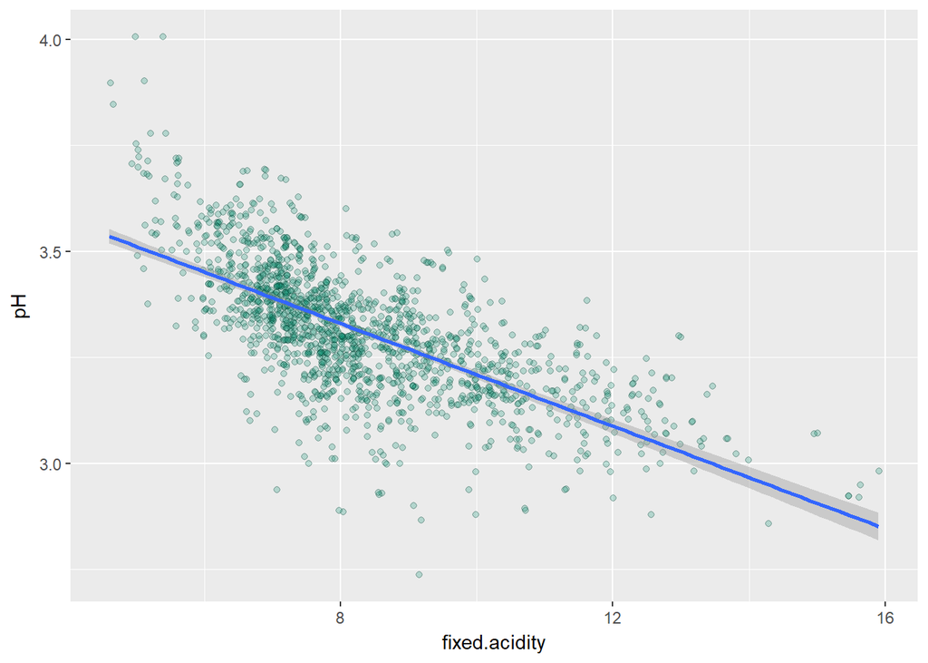

```
##
##  Pearson's product-moment correlation
##
## data:  wineRed$pH and wineRed$fixed.acidity
## t = -37.366, df = 1597, p-value < 2.2e-16
## alternative hypothesis: true correlation is not equal to 0
## 95 percent confidence interval:
##  -0.7082857 -0.6559174
## sample estimates:
##        cor
## -0.6829782
```

Fixed acidity Vs pH - From the plot, pH level is decreasing with increasing “fixed acidity”

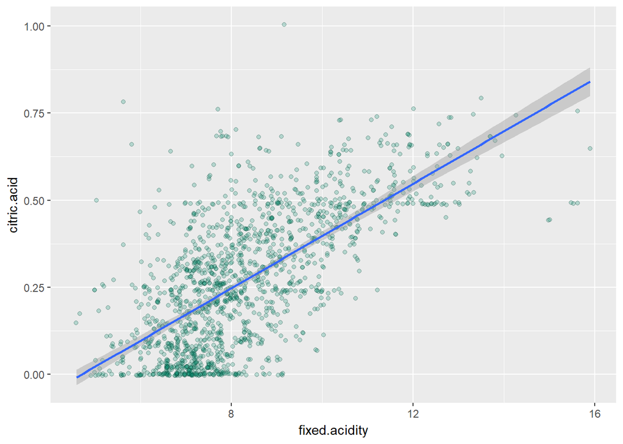

```
##
##  Pearson's product-moment correlation
##
## data:  wineRed$citric.acid and wineRed$fixed.acidity
## t = 36.234, df = 1597, p-value < 2.2e-16
## alternative hypothesis: true correlation is not equal to 0
## 95 percent confidence interval:
##  0.6438839 0.6977493
## sample estimates:
##       cor
## 0.6717034
```

Fixed acidity Vs Citric acid - Fixed acidity increasing with citric acid.

I am seeing outliers on the medium quality red wines. Also high quality red wine average alcohol contain is more that midium and low quality red wines.

Quality Vs Total Acidity

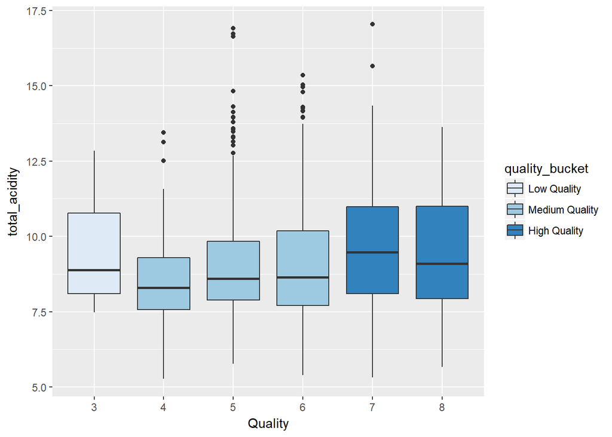

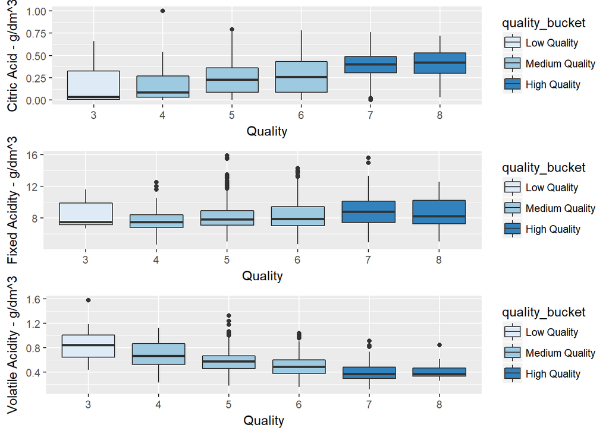

Analyze the corelation of each acidity with quality. Red wine Quality is increasing with citric acid and fixed acidity but decreasing with volatile acidity.

Look at the relationship between the quality and sulfur dioxide

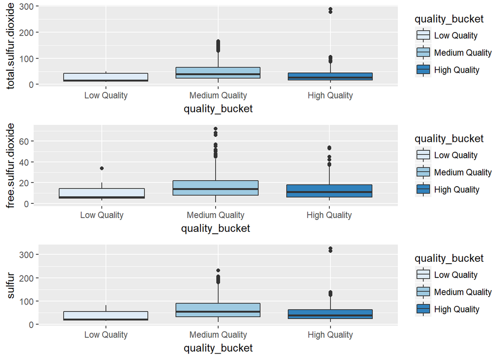

Medium quality has more total sulfur dioxide and low quality has less sulfur. I am not seing any correlation between the quality and the total sulfur.

Quality Vs Residual SUgar - Observed outliers in the midium and High quality wine.

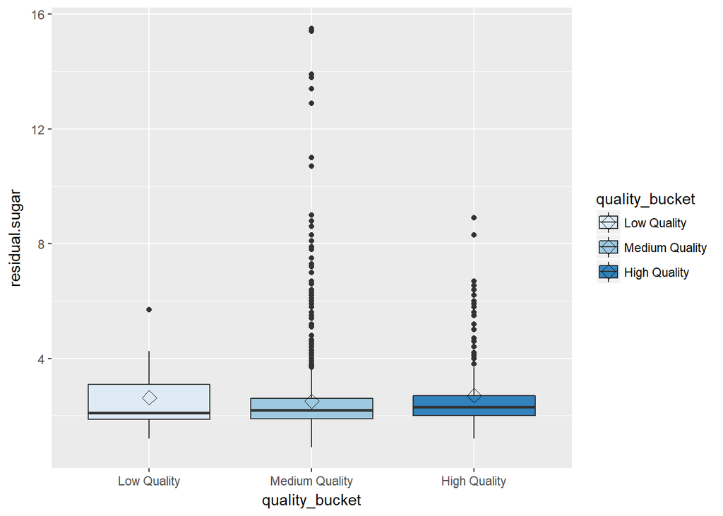

# Bivariate Analysis

#### 1. Talk about some of the relationships you observed in this part of the investigation. How did the feature(s) of interest vary with other features in the dataset?

We can see strong coorelation betwwen the following variable in the dataset fixed acidity Vs density (0.7) fixed acidity Vs citric acid (0.7) fixed acidity Vs pH (-0.7) Alcohol Vs density (-0.5)

#### 3. What was the strongest relationship you found?

Percentage of Alcohol variable has the strongest relationship with quality. High quality wine has high alcohol % compare to medium and low. Increasing percentage of Alcohol, the quality of the wine is high.

# Multivariate Plots Section

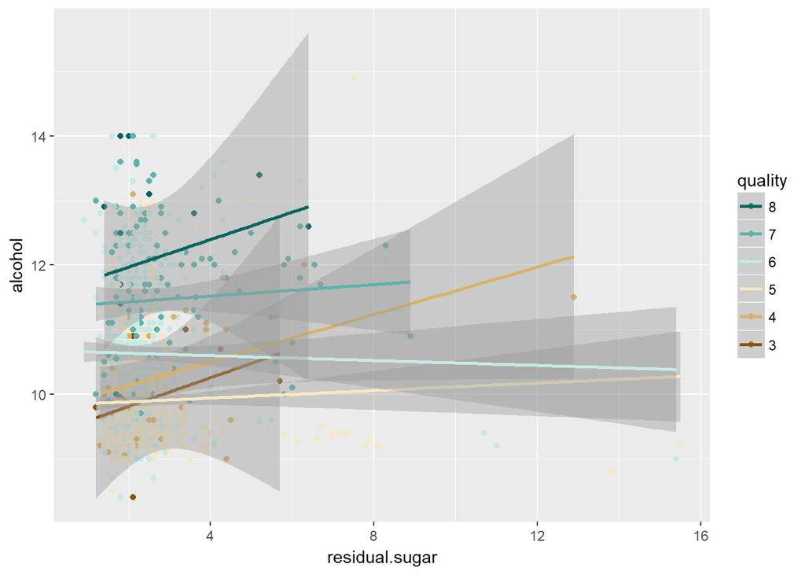

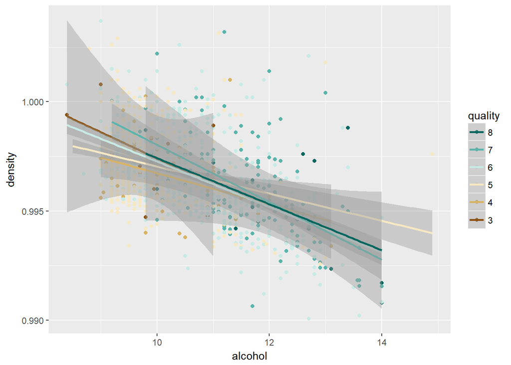

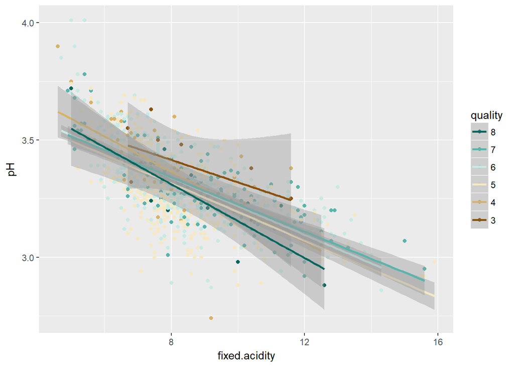

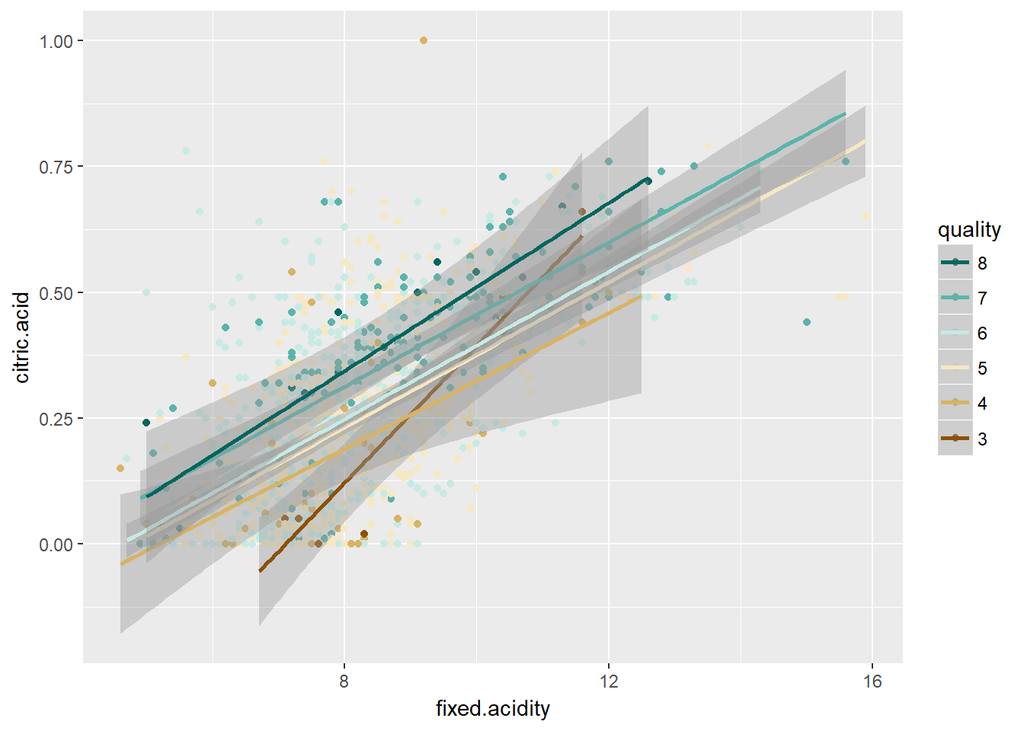

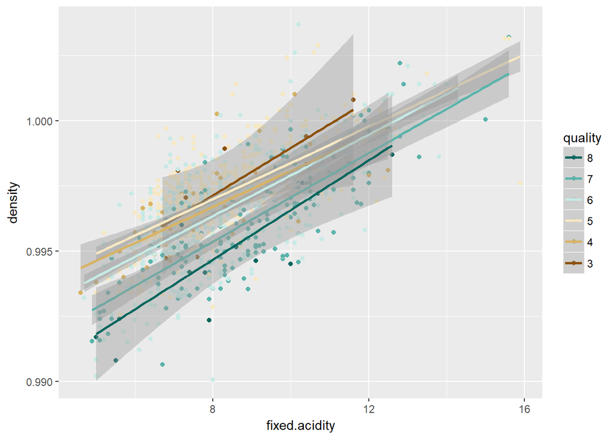

```
##
## Call:
## lm(formula = I(log(Quality)) ~ I(density^(1/3)) + alcohol + volatile.acidity +
##     fixed.acidity + total.sulfur.dioxide + residual.sugar + citric.acid,
##     data = wineRed)
##
## Residuals:
##      Min       1Q   Median       3Q      Max
## -1.27454 -0.09849 -0.00320  0.13469  0.52401
##
## Coefficients:
##                        Estimate Std. Error t value Pr(>|t|)
## (Intercept)           2.421e+00  1.602e+01   0.151   0.8799
## I(density^(1/3))     -1.849e+00  1.603e+01  -0.115   0.9082
## alcohol               8.143e-02  6.642e-03  12.259   <2e-16 ***
## volatile.acidity     -4.469e-01  3.530e-02 -12.659   <2e-16 ***
## fixed.acidity         1.394e-02  5.500e-03   2.535   0.0113 *
## total.sulfur.dioxide -2.624e-04  1.657e-04  -1.584   0.1134
## residual.sugar       -1.782e-06  4.303e-03   0.000   0.9997
## citric.acid          -9.540e-02  4.255e-02  -2.242   0.0251 *
## ---
## Signif. codes:  0 '***' 0.001 '**' 0.01 '*' 0.05 '.' 0.1 ' ' 1
##
## Residual standard error: 0.2004 on 1591 degrees of freedom
## Multiple R-squared:  0.2913, Adjusted R-squared:  0.2882
## F-statistic: 93.43 on 7 and 1591 DF,  p-value: < 2.2e-16
```

# Multivariate Analysis

#### 3. OPTIONAL: Did you create any models with your dataset? Discuss the strengths and limitations of your model.

# Final Plots and Summary

### Plot One

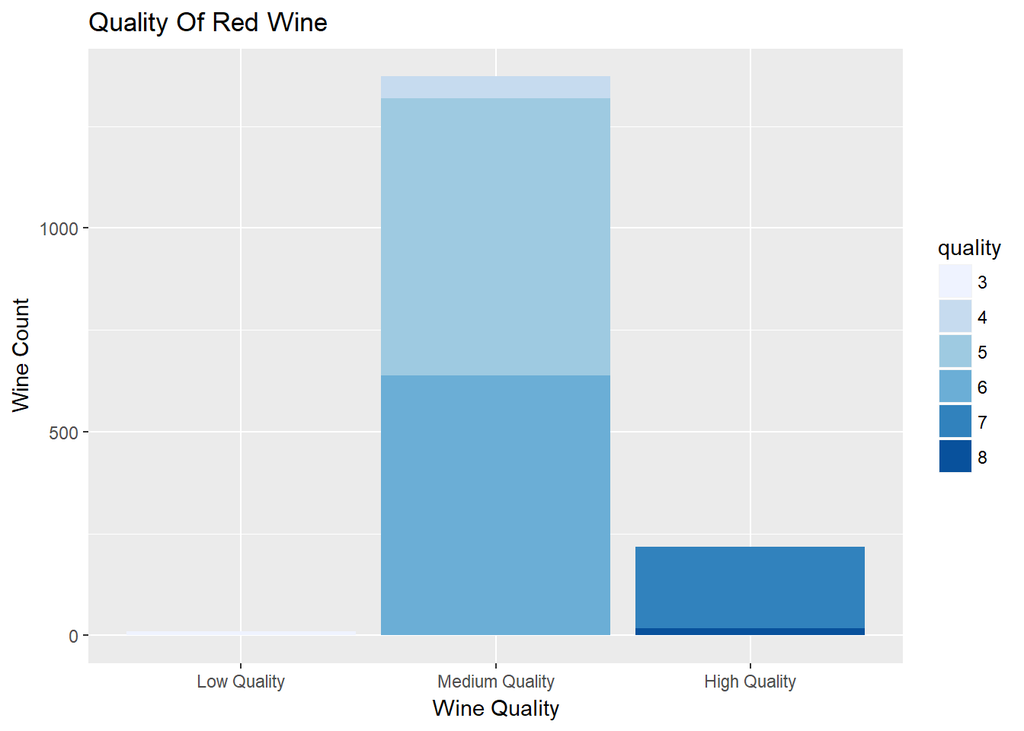

### Description One

Above ggplot tell us the industry producing Low, Medium and High Quality of Red wines. Also we can see the demand for the quality of the wine. Medium wine are in more demand than High quality and Low quality red wine.